# HURACANES Y TIFONES

Océano Atlántico y Pacífico (1851-2014)

Andrea Marin Domingo

Cargar los datos:

```r
load("C:/Users/Andrea/Documents/ProyHurac/CSVDatabase/huracanes.rdata")
```

## TABLA DE CONTENIDOS

- LIBRERÍAS
- VALORES
- ESTADÍSTICA DESCRIPTIVA
- INTERVALOS DE CONFIANZA
- CONTRASTES/INFERENCIA

### · LIBRERÍAS

```r
library(tidyverse)
library(devtools)
library(lubridate)
library(readxl)
library(flextable)
library(moments)
library(ggplot2)
library(janitor)
library(sf)
library(maps)
library(mapdata)
library(ggrepel)
library(gganimate)
library(dplyr)
library(DT)
library(rnaturalearth)
library(transformr)
library(rnaturalearthdata)
library(rgeos)
library(sp)
library(DescTools)
library(broom)
library(EnvStats)
library(PropCIs)
library(PairedData)
library(openair)
library(data.table)
library(gganimate)
```

### · VALORES USADOS

| **VARIABLES** | **DEFINICIÓN** |
| --- | --- |
| *LatMean* | Latitud media a la que se ha producido el huracán |
| *LatMax* | Latitud máxima que ha alcanzado |
| *LatMin* | Latitud mínima que ha alcanzado |
| *Longitude* | Longitud media a la que se ha producido el huracán |
| *LongMin* | Longitud mínima que ha alcanzado |
| *LongMax* | Longitud máxima que ha alcanzado |
| *meanWind* | Intensidad media del viento durante ese huracán |
| *minWind* | Intensidad mínima del viento durante ese huracán |
| *maxWind* | Intensidad máxima del viento durante ese huracán |
| *minPress* | Presión mínima |
| *maxPress* | Presión máxima |
| *meanPress* | Presión media |
| *Low Wind NE* | Radio máximo alcanzado por vientos de baja velocidad en dirección NE |
| *Low Wind SE* | Radio máximo alcanzado por vientos de baja velocidad en dirección SE |
| *Low Wind SW* | Radio máximo alcanzado por vientos de baja velocidad en dirección SW |
| *Low Wind NW* | Radio máximo alcanzado por vientos de baja velocidad en dirección NW |
| *Moderate Wind NE* | Radio máximo alcanzado por vientos de velocidad moderada en dirección NE |
| *Moderate Wind SE* | Radio máximo alcanzado por vientos de velocidad moderada en dirección SE |
| *Moderate Wind SW* | Radio máximo alcanzado por vientos de velocidad moderada en dirección SW |
| *Moderate Wind NW* | Radio máximo alcanzado por vientos de velocidad moderada en dirección NW |
| *High Wind NE* | Radio máximo alcanzado por vientos de alta velocidad en dirección NE |
| *High Wind SE* | Radio máximo alcanzado por vientos de alta velocidad en dirección SE |
| *High Wind SW* | Radio máximo alcanzado por vientos de alta velocidad en dirección SW |
| *High Wind NW* | Radio máximo alcanzado por vientos de alta velocidad en dirección NW |
| *duracion* | Duración del temporal en días |
| *difLong* | Diferencia entre las longitudes máxima y mínima alcanzadas por el huracán |
| *difLat* | Diferencia entre las latitudes máxima y mínima alcanzadas por el huracán |

Creamos nuestras variables principales: Océano Atlántico y Pacífico y Como en nuestra base de datos existen datos no numéricos, vamos a transformalos en numéricos:

```r
#Huracanes Océano Atlántico
huracanesAtlantico <- huracanes %>%
  filter(oceano=="Atlantico") %>%
  mutate(duracion=as.numeric(duracion))

#Huracanes Océano Pacífico
huracanesPacifico <- huracanes %>%
  filter(oceano=="Pacifico") %>%
  mutate(duracion=as.numeric(duracion))
```

La función recibe como argumentos, el estimador del parámetro y los límites inferior y superior del intervalo de confianza. Por defecto se redondean los valores a 4 dígitos y se considera que el nivel de confianza el 0.95. El valor del nivel de confianza se usa solamente para poner nombre a la variable que designa el intervalo, como suele ser habitual en publicaciones científicas

La función devuelve un data.frame con el estimador y el intervalo formateados con el número de dígitos indicado.

```r
formatInterval <- function(est, inf, sup, digits=4, conf.level=0.95){
  CI <- sprintf("(%s, %s)",round(inf,digits),round(sup,digits))
  estimate <- round(est,digits)
  df <- data.frame(estimate,CI, stringsAsFactors = FALSE)
  names(df)[2]=paste("CI",100*conf.level,"%",sep="")
  return(df)
}
```

La función devuelve un data.frame con el estimador y el intervalo formateados con el número de dígitos indicado. La opción `label` permite especificar una etiqueta para el nombre del estimador.

```r
formatInterval <- function(est, inf, sup, digits=4,
                           conf.level=0.95, label="Estimate"){
  CI <- sprintf("(%s, %s)",round(inf,digits),round(sup,digits))
  estimate <- round(est,digits)
  df <- data.frame(estimate,CI, stringsAsFactors = FALSE)
  names(df)=c(label,paste("CI",100*conf.level,"%",sep=""))
  return(df)
}
```

### · ESTADÍSTICA DESCRIPTIVA

#### Problema 1

Para cada una de estas variables se deben calcular los siguientes estadísticos descriptivos (para cada océano por separado):

- Número de valores válidos y número de valores perdidos.
- Media, sd, mediana, cuartil 25, cuartil 75, mínimo, máximo, asimetría, curtosis.

Estos valores deben presentarse en tablas para cada grupo de variables afines (latitudes, longitudes,viento, presion, Low-Moderate-High, duracion-diflong-diflat)

##### OCÉANO ATLÁNTICO

HURACANES/TIFONES MEDIDOS Y PERDIDOS EN EL OCÉANO ATLÁNTICO

| Mediciones | medidos | noMedidos |
| --- | --- | --- |
| difLat | 27 | 0 |
| difLong | 27 | 0 |
| duracion | 27 | 0 |
| High Wind NE | 0 | 27 |
| High Wind NW | 0 | 27 |
| High Wind SE | 0 | 27 |
| High Wind SW | 0 | 27 |
| LatMax | 27 | 0 |
| LatMean | 27 | 0 |
| LatMin | 27 | 0 |
| LongMax | 27 | 0 |
| LongMean | 27 | 0 |
| LongMin | 27 | 0 |
| Low Wind NE | 0 | 27 |
| Low Wind NW | 0 | 27 |
| Low Wind SE | 0 | 27 |
| Low Wind SW | 0 | 27 |
| maxPress | 4 | 23 |
| maxWind | 27 | 0 |
| meanPress | 4 | 23 |
| meanWind | 27 | 0 |
| minPress | 4 | 23 |
| minWind | 27 | 0 |
| Moderate Wind NE | 0 | 27 |
| Moderate Wind NW | 0 | 27 |
| Moderate Wind SE | 0 | 27 |
| Moderate Wind SW | 0 | 27 |

DESCRIPCIÓN DE VARIABLES ESTADÍSTICAS:OCÉANO ATLÁNTICO

| Variables | Media | Sd | Asimetria | Curtosis | Min | Mediana | Max |
| --- | --- | --- | --- | --- | --- | --- | --- |
| difLat | 15.801323 | 12.354623 | 0.84396256 | 0.03367009 | 0.000000 | 12.60000 | 60.80000 |
| difLong | 20.981533 | 18.607534 | 4.33432452 | 61.42498012 | 0.000000 | 16.80000 | 358.90000 |
| duracion | 7.264609 | 4.200372 | 1.16917759 | 1.92693588 | 1.000000 | 6.00000 | 33.00000 |
| High Wind NE | 21.085859 | 34.486188 | 2.25427366 | 6.04705603 | 0.000000 | 0.00000 | 180.00000 |
| High Wind NW | 15.606061 | 29.144073 | 2.81526165 | 10.27920193 | 0.000000 | 0.00000 | 180.00000 |
| High Wind SE | 19.419192 | 31.958746 | 2.77389940 | 13.23140951 | 0.000000 | 0.00000 | 250.00000 |
| High Wind SW | 12.828283 | 22.811984 | 2.40453429 | 7.53913606 | 0.000000 | 0.00000 | 150.00000 |
| LatMax | 35.878666 | 12.428210 | 0.13786771 | -0.42784519 | 9.000000 | 35.50000 | 81.00000 |
| LatMean | 26.747411 | 7.422456 | -0.03828632 | -0.36912419 | 8.184615 | 27.39000 | 53.38261 |
| LatMin | 20.077343 | 7.034963 | 0.41515273 | -0.62191697 | 7.200000 | 19.40000 | 45.00000 |
| LongMax | -54.950221 | 23.711694 | 0.28801856 | -0.37899546 | -98.000000 | -56.15000 | 63.00000 |
| LongMean | -67.722284 | 18.012826 | 0.36263780 | -0.63876826 | -102.030303 | -69.47917 | -15.62000 |
| LongMin | -75.931753 | 18.394089 | -1.51621903 | 30.22724920 | -359.100000 | -77.95000 | -20.60000 |
| Low Wind NE | 144.393939 | 116.310177 | 1.55457384 | 3.53505375 | 0.000000 | 120.00000 | 710.00000 |
| Low Wind NW | 104.570707 | 101.548631 | 1.60942142 | 2.92645653 | 0.000000 | 75.00000 | 530.00000 |
| Low Wind SE | 143.383838 | 121.652806 | 1.37558007 | 2.14026766 | 0.000000 | 120.00000 | 600.00000 |
| Low Wind SW | 98.131313 | 114.307862 | 1.70198418 | 3.15492919 | 0.000000 | 60.00000 | 640.00000 |
| maxPress | 1,001.298058 | 16.261693 | -2.10929050 | 4.45572022 | 918.000000 | 1,008.00000 | 1,024.00000 |
| maxWind | 66.126792 | 33.556193 | -0.75257746 | 4.79740109 | -99.000000 | 65.00000 | 165.00000 |
| meanPress | 990.856000 | 16.996763 | -1.22786475 | 1.23328670 | 918.000000 | 995.53571 | 1,019.14286 |
| meanWind | 46.482786 | 23.124433 | -2.36030887 | 14.43064699 | -99.000000 | 45.00000 | 99.82759 |
| minPress | 978.479612 | 24.252059 | -0.89978189 | 0.28002022 | 882.000000 | 984.50000 | 1,016.00000 |
| minWind | 24.321940 | 27.860023 | -3.35400322 | 13.33295017 | -99.000000 | 25.00000 | 90.00000 |
| Moderate Wind NE | 52.297980 | 61.748196 | 1.78710968 | 4.49997082 | 0.000000 | 35.00000 | 360.00000 |
| Moderate Wind NW | 39.444444 | 58.130297 | 2.44076547 | 7.76643447 | 0.000000 | 20.00000 | 360.00000 |
| Moderate Wind SE | 49.368687 | 61.187325 | 1.54051360 | 2.33496367 | 0.000000 | 30.00000 | 300.00000 |
| Moderate Wind SW | 35.782828 | 52.452718 | 2.14965309 | 6.12316650 | 0.000000 | 15.00000 | 330.00000 |

##### OCÉANO PACÍFICO

HURACANES/TIFONES MEDIDOS EN EL OCÉANO PACÍFICO

| Mediciones | medidos | noMedidos |
| --- | --- | --- |
| difLat | 27 | 0 |
| difLong | 27 | 0 |
| duracion | 27 | 0 |
| High Wind NE | 0 | 27 |
| High Wind NW | 0 | 27 |
| High Wind SE | 0 | 27 |
| High Wind SW | 0 | 27 |
| LatMax | 27 | 0 |
| LatMean | 27 | 0 |
| LatMin | 27 | 0 |
| LongMax | 27 | 0 |
| LongMean | 27 | 0 |
| LongMin | 27 | 0 |
| Low Wind NE | 0 | 27 |
| Low Wind NW | 0 | 27 |
| Low Wind SE | 0 | 27 |
| Low Wind SW | 0 | 27 |
| maxPress | 5 | 22 |
| maxWind | 27 | 0 |
| meanPress | 5 | 22 |
| meanWind | 27 | 0 |
| minPress | 5 | 22 |
| minWind | 27 | 0 |
| Moderate Wind NE | 0 | 27 |
| Moderate Wind NW | 0 | 27 |
| Moderate Wind SE | 0 | 27 |
| Moderate Wind SW | 0 | 27 |

DESCRIPCIÓN DE VARIABLES ESTADÍSTICAS:OCÉANO PACÍFICO

| Variables | Media | Sd | Asimetria | Curtosis | Min | Mediana | Max |
| --- | --- | --- | --- | --- | --- | --- | --- |
| difLat | 7.613524 | 5.323770 | 1.3950585 | 3.34246450 | 0.0000 | 6.70000 | 40.20000 |
| difLong | 23.973619 | 49.618140 | 6.1522930 | 38.74229684 | 0.0000 | 14.60000 | 359.90000 |
| duracion | 6.926667 | 3.695945 | 1.3902078 | 3.94290279 | 1.0000 | 6.00000 | 31.00000 |
| High Wind NE | 13.688889 | 17.351181 | 1.2277747 | 1.75420920 | 0.0000 | 0.00000 | 100.00000 |
| High Wind NW | 11.644444 | 15.689731 | 1.5064363 | 3.56960203 | 0.0000 | 0.00000 | 100.00000 |
| High Wind SE | 11.777778 | 15.212614 | 1.0958509 | 0.64317309 | 0.0000 | 0.00000 | 75.00000 |
| High Wind SW | 9.533333 | 13.350696 | 1.4225663 | 2.22508587 | 0.0000 | 0.00000 | 75.00000 |
| LatMax | 21.088000 | 5.521516 | 1.1067371 | 3.09713054 | 7.0000 | 20.30000 | 54.00000 |
| LatMean | 17.116908 | 3.295758 | 0.6596228 | 3.10627628 | 5.9000 | 16.94022 | 37.15000 |
| LatMin | 13.474476 | 2.970243 | 1.0217446 | 4.04805596 | 4.2000 | 13.10000 | 34.40000 |
| LongMax | -103.319619 | 42.701434 | 5.6955562 | 35.68740903 | -177.9000 | -106.10000 | 179.90000 |
| LongMean | -116.316300 | 20.450758 | 2.4184172 | 20.06359275 | -178.9389 | -114.10166 | 56.74524 |
| LongMin | -127.293238 | 19.779640 | -0.9686835 | 0.37571131 | -180.0000 | -122.50000 | -88.00000 |
| Low Wind NE | 77.933333 | 55.878296 | 0.6019215 | 0.67948321 | 0.0000 | 75.00000 | 300.00000 |
| Low Wind NW | 70.533333 | 87.553198 | 9.1740365 | 115.42242017 | 0.0000 | 60.00000 | 1,180.00000 |
| Low Wind SE | 71.244444 | 52.697399 | 0.8018067 | 1.39197864 | 0.0000 | 70.00000 | 270.00000 |
| Low Wind SW | 55.888889 | 42.729016 | 0.3870171 | -0.20087330 | 0.0000 | 60.00000 | 180.00000 |
| maxPress | 1,006.929760 | 9.033613 | -4.3961763 | 24.41954672 | 933.0000 | 1,009.00000 | 1,021.00000 |
| maxWind | 67.671429 | 30.285921 | 0.7671521 | -0.28558075 | 20.0000 | 60.00000 | 185.00000 |
| meanPress | 995.764147 | 12.015532 | -1.6048590 | 3.41242338 | 933.0000 | 999.77143 | 1,009.90000 |
| meanWind | 45.571559 | 15.125182 | 0.7167325 | -0.31218231 | 20.0000 | 43.17895 | 97.77778 |
| minPress | 978.815157 | 25.262603 | -0.9791031 | 0.16721608 | 872.0000 | 987.00000 | 1,009.00000 |
| minWind | 27.376190 | 11.650962 | 2.7958927 | 8.20881717 | 10.0000 | 25.00000 | 75.00000 |
| Moderate Wind NE | 29.822222 | 30.781697 | 0.7475066 | -0.05262870 | 0.0000 | 30.00000 | 150.00000 |
| Moderate Wind NW | 25.422222 | 27.965611 | 0.9448787 | 0.72349323 | 0.0000 | 20.00000 | 150.00000 |
| Moderate Wind SE | 26.444444 | 28.909152 | 0.9933583 | 0.95708740 | 0.0000 | 20.00000 | 150.00000 |
| Moderate Wind SW | 21.400000 | 24.282931 | 0.8814450 | 0.01438155 | 0.0000 | 20.00000 | 105.00000 |

#### Problema 2

Las distribuciones de estas variables deben representarse mediante histogramas, que se presentarán agrupados en facetas mediante `facet_wrap()`.

##### DURACIÓN

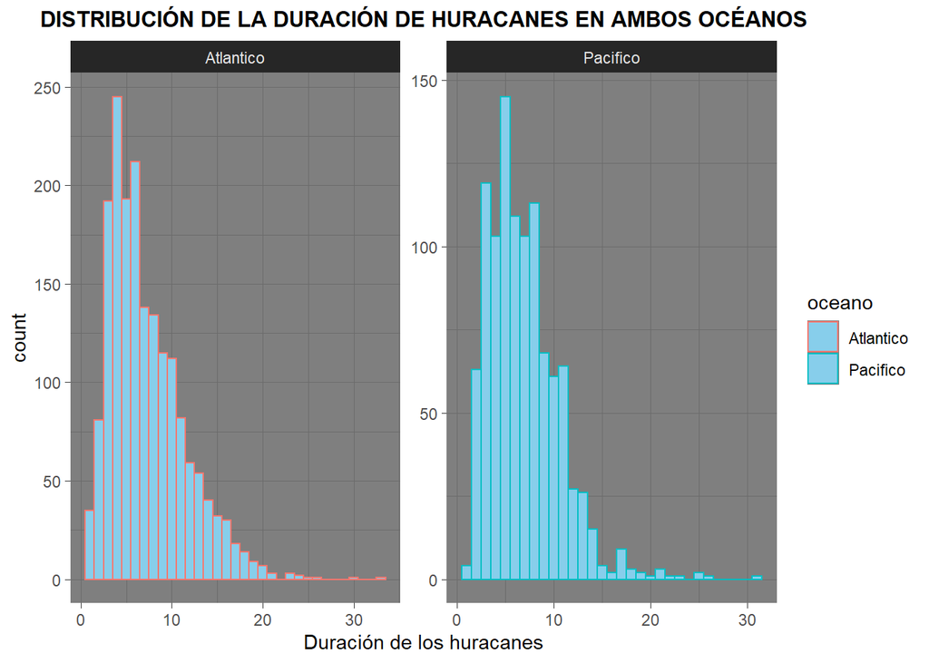

##### LONGITUDES

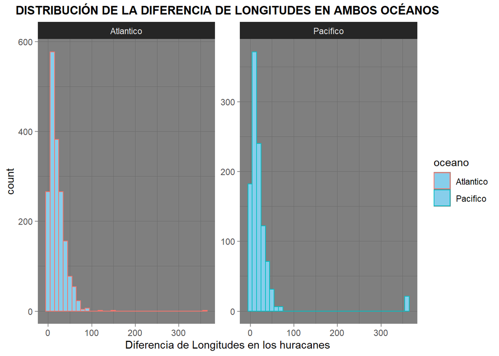

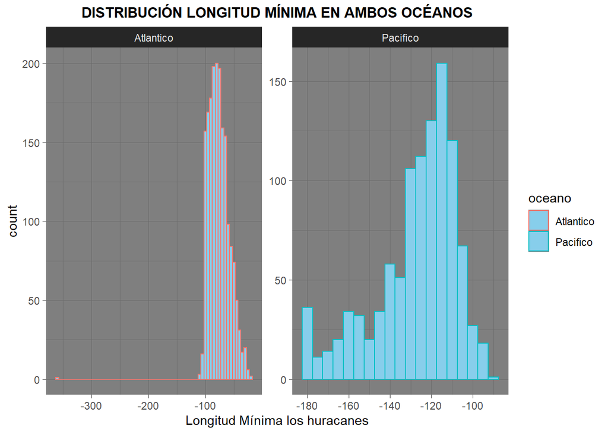

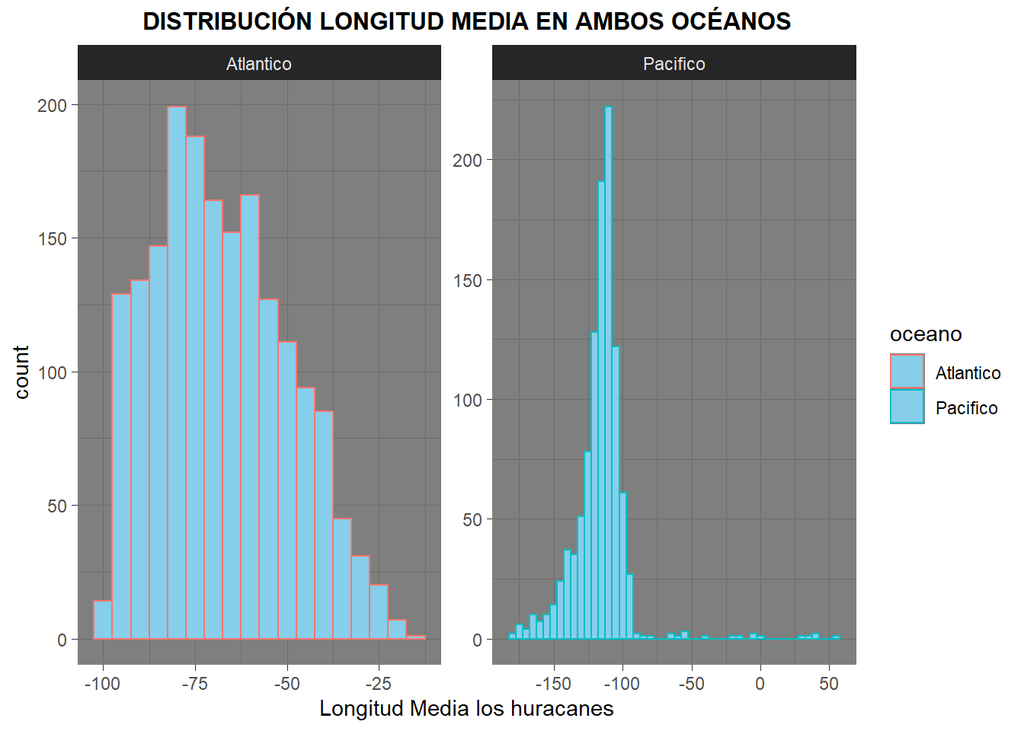

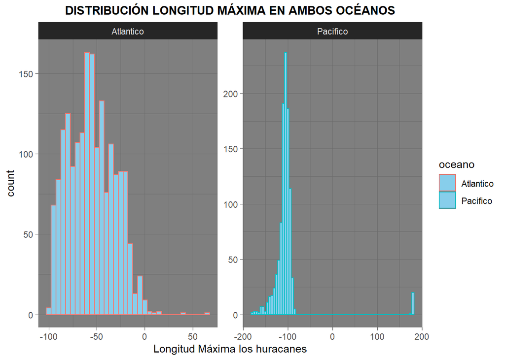

##### LATITUDES

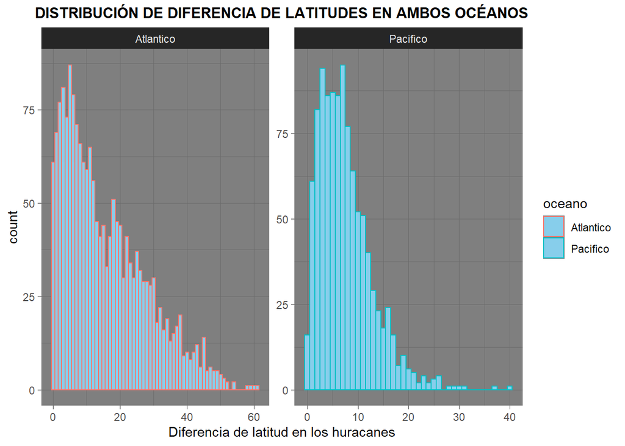

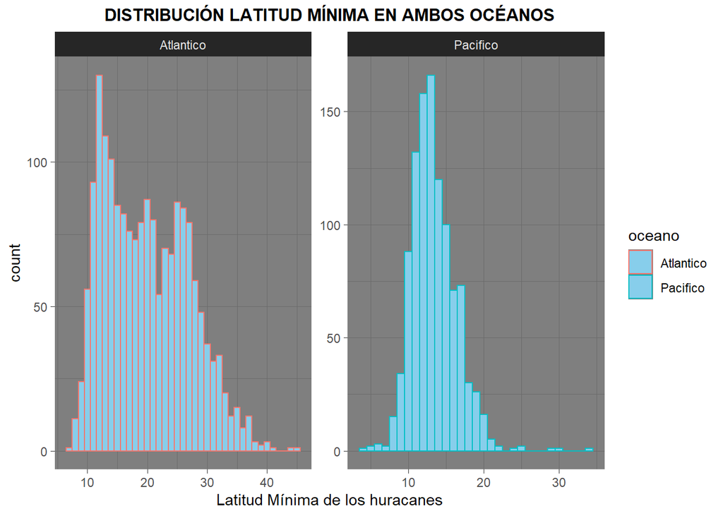

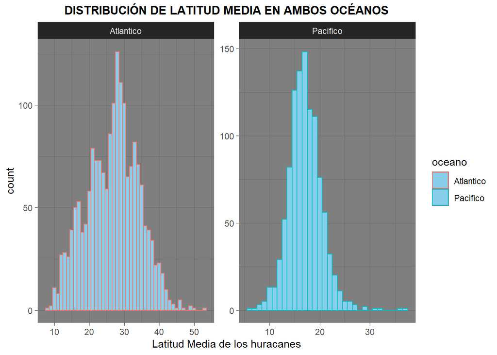

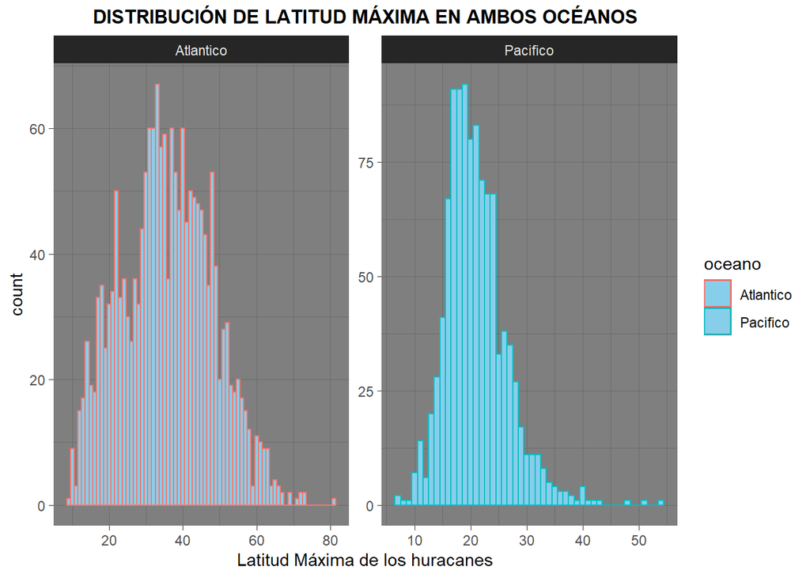

##### PRESIÓN

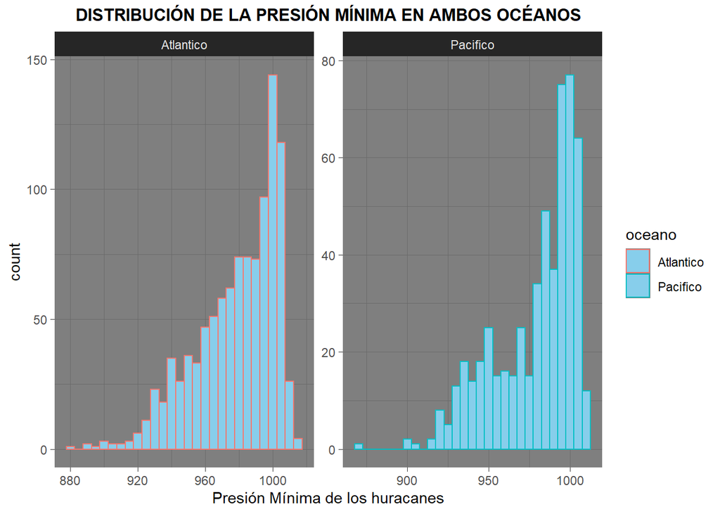

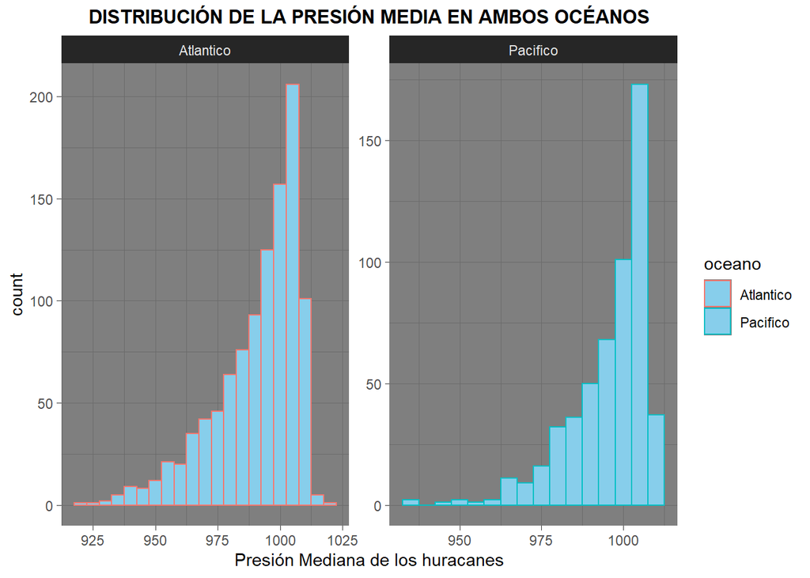

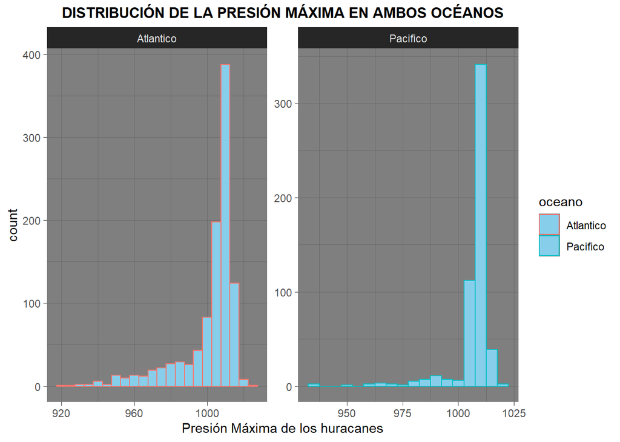

##### VIENTO

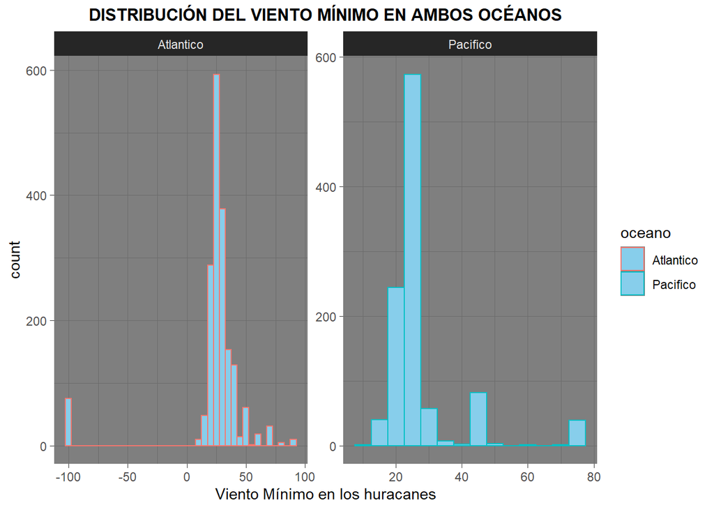

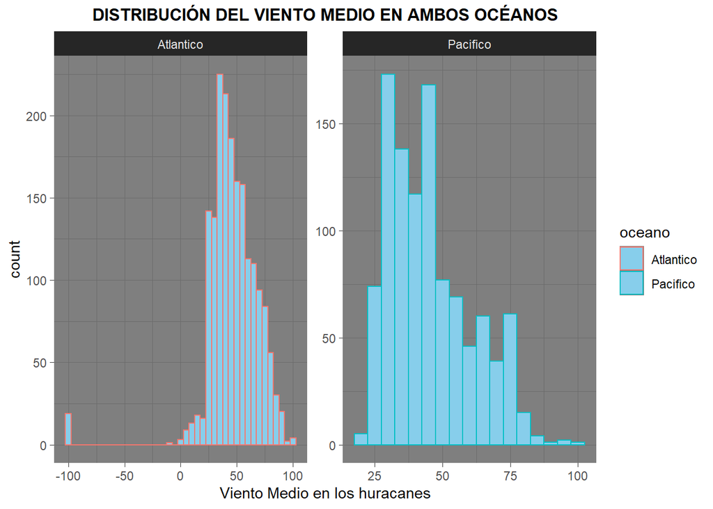

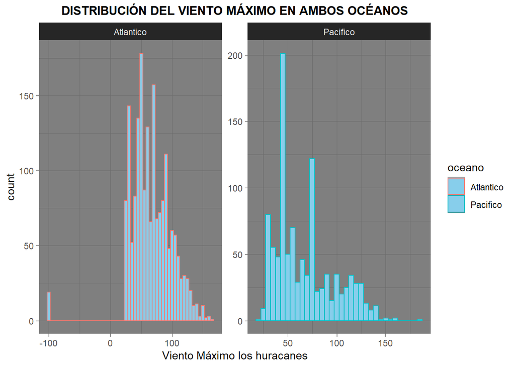

#### Problema 3

Contar el número de huracanes ocurridos en periodos de 5 años (desde 1851) en cada uno de los dos océanos y representarlos en un diagrama de barras.

##### OCÉANO ATLÁNTICO

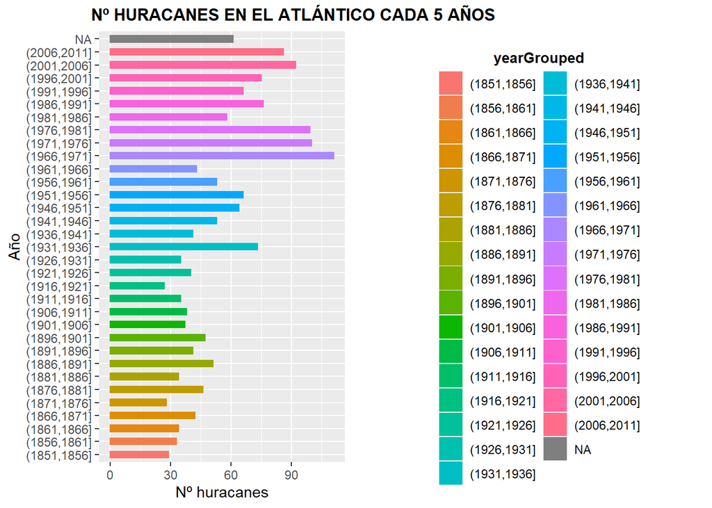

##### OCÉANO PACÍFICO

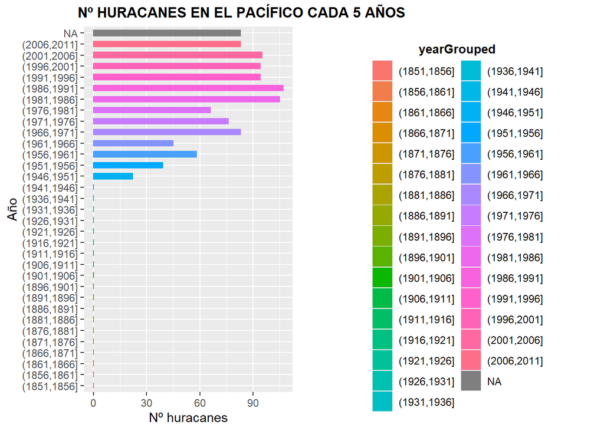

#### Problema 4

Para cada oceano contar el número de huracanes cada mes en periodos de 25 años, esto es: número de huracanes en enero entre 1851 y 1875, entre 1876 y 1900, etc; lo mismo para febrero, marzo, etc. Como resultado se debe obtener una tabla cruzada con los meses en filas y los periodos de 25 años en columnas. Representar estos valores gráficamente y explorar si existe alguna tendencia.

##### OCÉANO ATLÁNTICO

Nº HURACANES/MES CADA 25 AÑOS

| Mes/Año | (1851,1876] | (1876,1901] | (1901,1926] | (1926,1951] | (1951,1976] | (1976,2001] |
| --- | --- | --- | --- | --- | --- | --- |
| Enero | 0.0 (0) | 0.0 (0) | 0.0 (0) | 0.0 (2) | 0.0 (1) | 0.0 (1) |
| Febrero | 0.0 (0) | 0.0 (0) | 0.0 (0) | 0.0 (0) | 0.0 (1) | 0.0 (0) |
| Marzo | 0.0 (0) | 0.0 (0) | 0.0 (1) | 0.0 (0) | 0.0 (0) | 0.0 (0) |
| Abril | 0.0 (0) | 0.0 (0) | 0.0 (0) | 0.0 (0) | 0.0 (1) | 0.0 (3) |
| Mayo | 0.0 (1) | 0.0 (4) | 0.0 (2) | 0.0 (6) | 0.0 (7) | 0.0 (2) |
| Junio | 0.0 (8) | 0.1 (11) | 0.1 (14) | 0.0 (8) | 0.1 (33) | 0.1 (25) |
| Julio | 0.1 (9) | 0.0 (10) | 0.1 (10) | 0.1 (14) | 0.1 (34) | 0.1 (38) |
| Agosto | 0.2 (35) | 0.2 (43) | 0.2 (29) | 0.2 (46) | 0.2 (60) | 0.2 (79) |
| Setiembre | 0.4 (66) | 0.3 (69) | 0.4 (63) | 0.4 (98) | 0.4 (140) | 0.3 (124) |
| Octubre | 0.3 (43) | 0.3 (64) | 0.2 (44) | 0.3 (69) | 0.2 (73) | 0.2 (71) |
| Noviembre | 0.0 (4) | 0.1 (13) | 0.1 (13) | 0.1 (21) | 0.1 (20) | 0.1 (26) |
| Dieciembre | 0.0 (0) | 0.0 (5) | 0.0 (1) | 0.0 (2) | 0.0 (3) | 0.0 (5) |

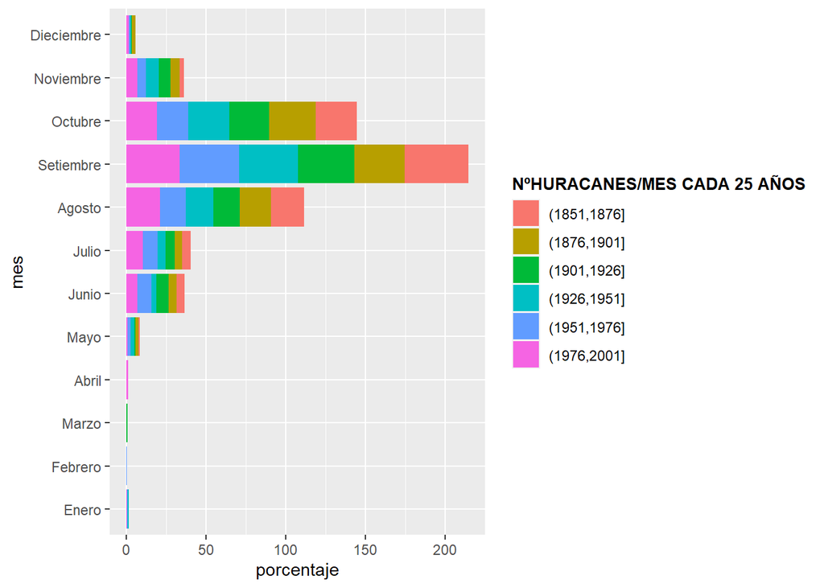

##### OCÉANO PACÍFICO

Nº HURACANES/MES CADA 25 AÑOS

| Mes/Año | (1926,1951] | (1951,1976] | (1976,2001] |
| --- | --- | --- | --- |
| Febrero | 0.0 (0) | 0.0 (0) | 0.0 (1) |
| Marzo | 0.0 (0) | 0.0 (0) | 0.0 (1) |
| Mayo | 0.0 (1) | 0.0 (4) | 0.0 (11) |
| Junio | 0.2 (5) | 0.1 (38) | 0.1 (54) |
| Julio | 0.1 (3) | 0.2 (61) | 0.2 (98) |
| Agosto | 0.2 (5) | 0.2 (61) | 0.2 (110) |
| Setiembre | 0.3 (6) | 0.3 (79) | 0.2 (103) |
| Octubre | 0.0 (1) | 0.2 (48) | 0.2 (72) |
| Noviembre | 0.0 (1) | 0.0 (9) | 0.0 (14) |
| Dieciembre | 0.0 (0) | 0.0 (1) | 0.0 (2) |

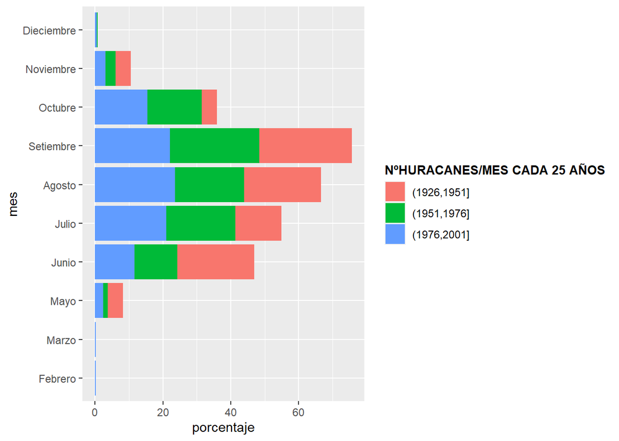

#### Problema 5

Explorar la intensidad y duración de los huracanes a lo largo del tiempo, así como las relaciones entre estas variables.

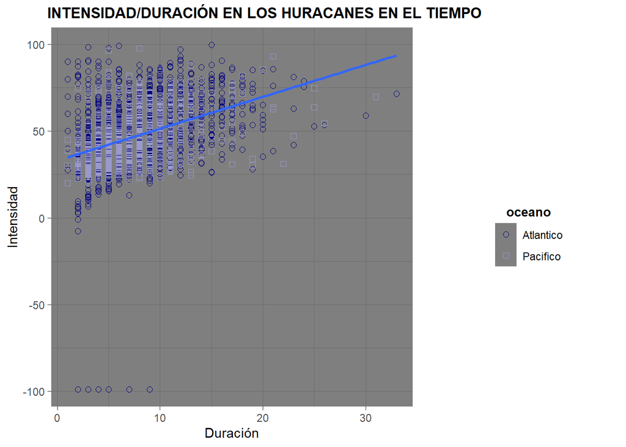

En el gráfico podemos observar como hay una línea de tendencia que se inicia a partir de una intensidad de 40 Km/h aproximadamente, aunque si observamos, en el Atlántico encontramos huracanes con una intensidad menos de 0, pero con poca duración, en cambio, hay huracanes con una intensidad mayor de 50 Km/h con una duración mayor de 30 días. En el Pacífico podemos encontrar similitudes, como el núm. de huracanes con mayor intensidad y duración, aunque no hay huracanes con una duración menos de 10 días y una intensidad menos de 0.

#### Problema 6

Explorar las relaciones existentes entre las variables presión y velocidad del viento.

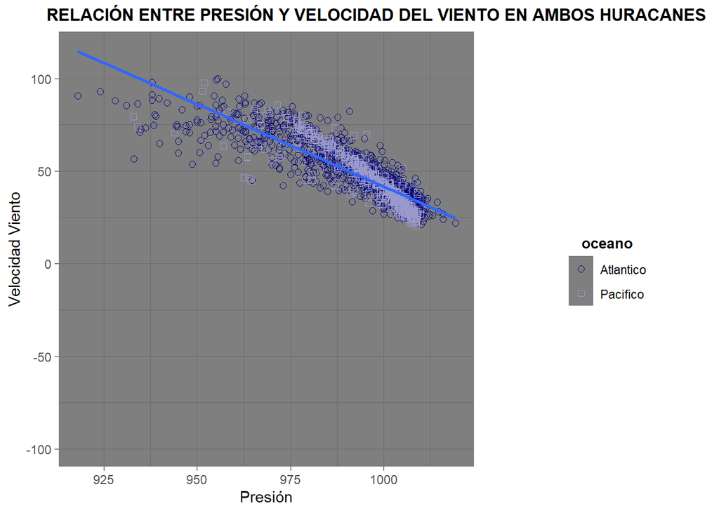

En este gráfico observamos como hay un mayor número de huracanes, tanto del Atlántico como del Pacífico, con una presión entre los 1000-1050 pascales y una velocidad de unos 25 Km/h del viento. Esto es el mayor rango de huracanes encontrados, aunque como diferencia de ambos, podemos encontrar en el Atlántico huracanes con una presión menor de 925 y un viento muy fuerte, casi unos 100 Km/h.

#### Problema 7

Explorar las relaciones existentes entre los radios alcanzados por los vientos en las distintas direcciones.

##### VIENTO SUAVE

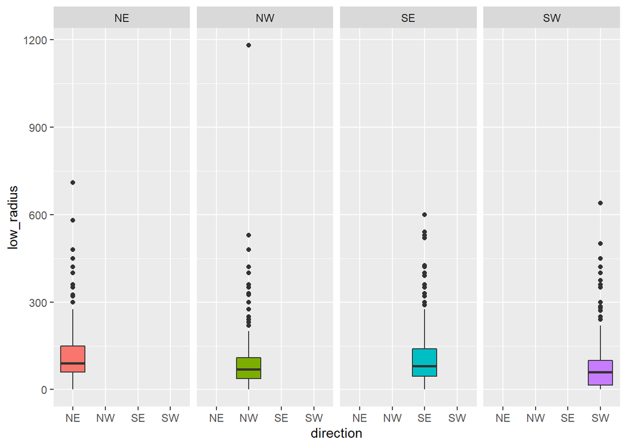

##### VIENTO FUERTE

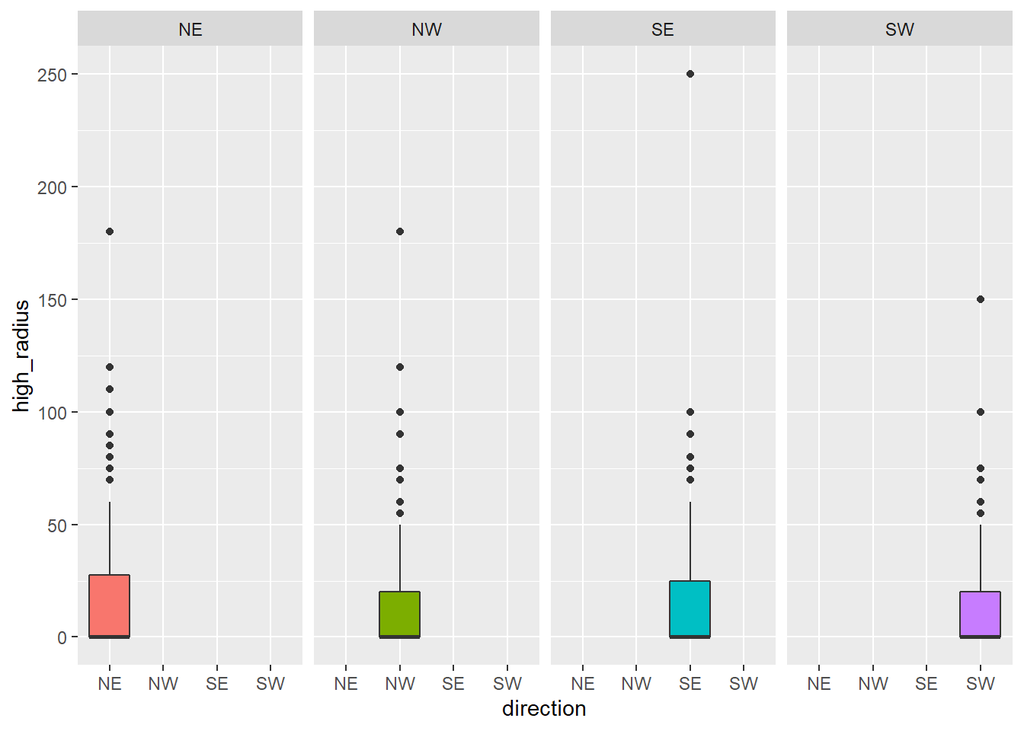

##### VIENTO MODERADO

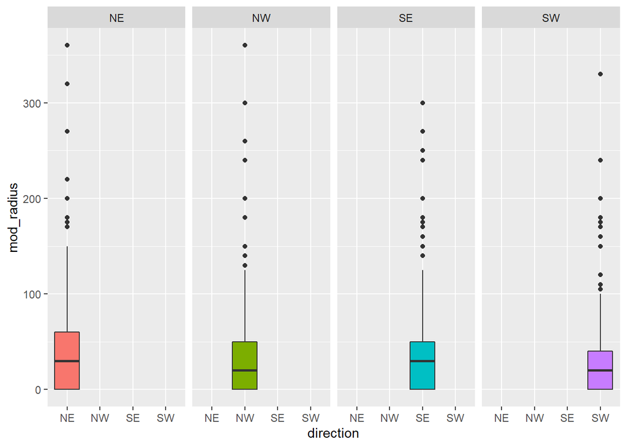

#### Problema 8

Explorar las relaciones existentes entre el recorrido del huracán (diferencias en latitud y longitud) y la intensidad (velocidad del viento) y duración.

##### OCÉANO ATLÁNTICO

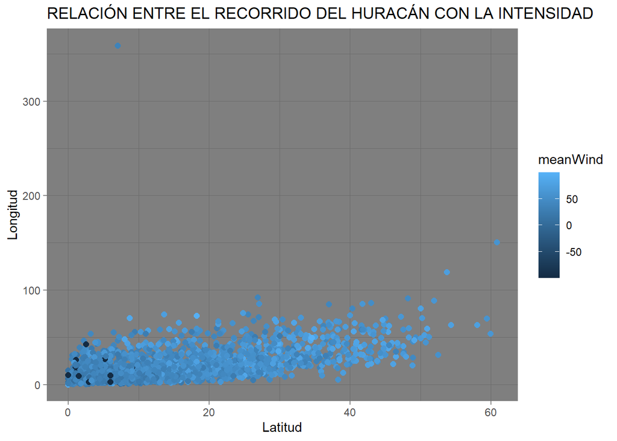

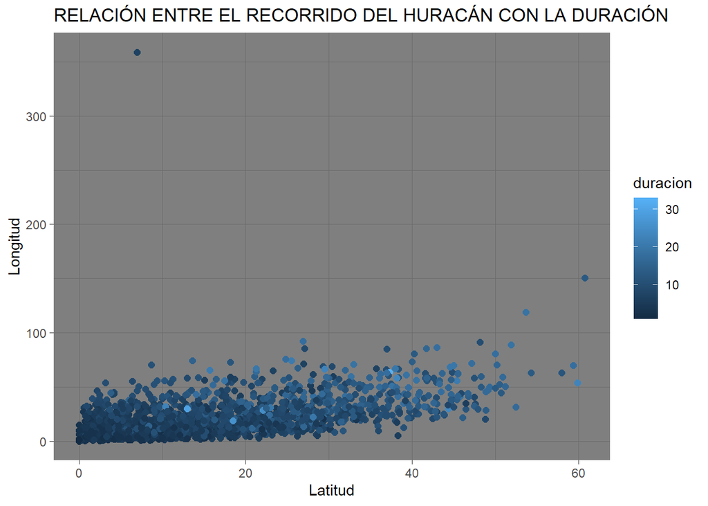

##### OCÉANO PACÍFICO

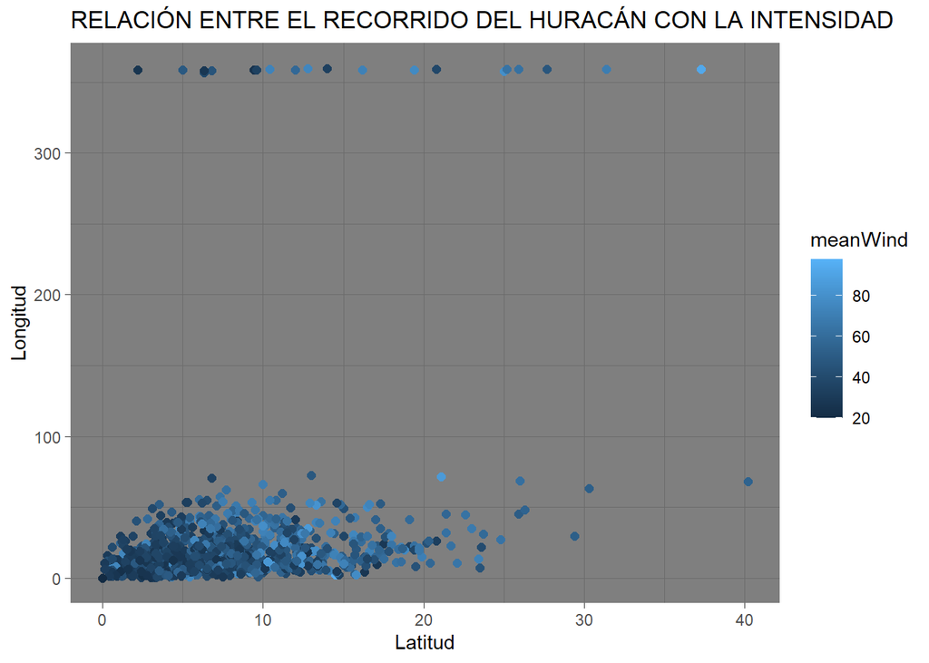

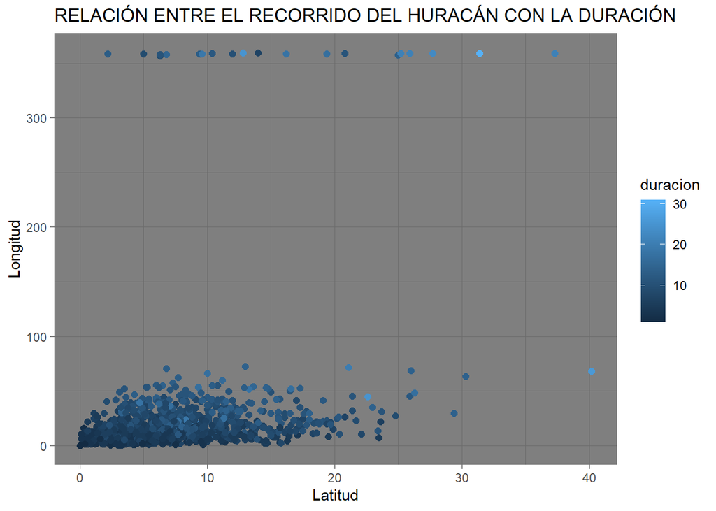

#### Problema 9

Representar las posiciones de los huracanes sobre un mapa.

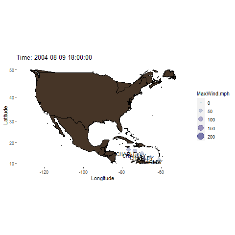

### · INTERVALOS DE CONFIANZA

#### Problema 1

Calcular, para cada uno de los dos océanos, intervalos de confianza al 95% para la media y desviación típica de las siguientes variables numéricas:

- meanWind: intensidad media del viento durante ese huracán
- meanPress: presión media
- duracion: Duración del temporal en días
- difLong: Diferencia entre las longitudes máxima y mínima alcanzadas por el huracán
- difLat: Diferencia entre las latitudes máxima y mínima alcanzadas por el huracán

##### OCÉANO ATLÁNTICO

MEDIAS ESTIMADAS E INTERVALOS DE CONFIANZA AL 95%

| Variable | Estimate | CI95% |
| --- | --- | --- |
| difLat | 15.80 | (15.23, 16.37) |
| difLong | 20.98 | (20.12, 21.84) |
| duracion | 7.26 | (7.07, 7.46) |
| meanPress | 990.86 | (989.82, 991.9) |
| meanWind | 46.48 | (45.42, 47.55) |

##### OCÉANO PACÍFICO

MEDIAS ESTIMADAS E INTERVALOS DE CONFIANZA AL 95%

| Variable | Estimate | CI95% |
| --- | --- | --- |
| difLat | 7.61 | (7.29, 7.94) |
| difLong | 23.97 | (20.97, 26.98) |
| duracion | 6.93 | (6.7, 7.15) |
| meanPress | 995.76 | (994.75, 996.78) |
| meanWind | 45.57 | (44.66, 46.49) |

#### Problema 2

Calcular, para cada océano, un intervalo de confianza al 95% para la proporción de huracanes que se producen en el mes de septiembre.

##### OCÉANO ATLÁNTICO

INTERVALO DE CONFIANZA AL 95% EN SETIEMBRE

| Estimate | CI95% |
| --- | --- |
| 0.3523 | (0.3306, 0.3745) |

##### OCÉANO PACÍFICO

INTERVALO DE CONFIANZA AL 95% EN SETIEMBRE

| Estimate | CI95% |
| --- | --- |
| 0.2371 | (0.2124, 0.2638) |

A partir de los datos obtenidos sobre los intervalos de Confianza en cada Océano sobre la cantidad de huracanes en tan solo el mes de setiembre, podemos observar que hay un porcentaje mayor en el Atlántico, con un 35% aproximadamente, en cambio, en el Pacífico, un 24% aproximadamente. Normalmente, los huracanes se forman en las épocas más calurosas, su mayor actividad ciclónica suele tener lugar hacia finales de verano, aunque cada región tiene su período de temporada. En el caso del Océano Atlántico tiene lugar entre principios de junio y finales de setiembre, con un pico máximo entre el 10 de setiembre aproximadamente. Por este motivo, nuestro intervalo de Confianza es alto en el mes de setiembre. En cambio, en el Océano Pacífico tiene un período de temporada más amplio, ya que al ser un Océano tan grande se divide en varias regiones.(Aunque tiene un margen similar al Atlántico)En el noroeste del Pacífico, tiene su período de temporada entre el abril y enero, con un mínimo en febrero, marzo y un máximo en principios de setiembre. Por dicho motivo, el intervalo de Confianza es menor en el Pacífico.

#### Problema 3

Calcular la proporción de huracanes en el atlántico cuya velocidad máxima mayor o igual que 80 km/h. Repetir para el Pacífico.

##### OCÉANO ATLÁNTICO

NºHURACANES CON VELOCIDAD MÁXIMA MAYOR O IGUAL 80 Km/h

| Estimate | CI95% |
| --- | --- |
| 0.3004 | (0.2798, 0.3219) |

##### OCÉANO PACÍFICO

NºHURACANES CON VELOCIDAD MÁXIMA MAYOR O IGUAL 80 Km/h

| Estimate | CI95% |
| --- | --- |
| 0.2695 | (0.2436, 0.2972) |

#### Problema 4

Compara e interpreta mediante intervalos de confianza los valores medios y las desviaciones típicas de las siguientes variables entre los dos océanos, Atlántico y Pacífico.

- meanWind: intensidad media del viento durante ese huracán
- meanPress: presión media
- duracion: Duración del temporal en días
- difLong: Diferencia entre las longitudes máxima y mínima alcanzadas por el huracán
- difLat: Diferencia entre las latitudes máxima y mínima alcanzadas por el huracán

##### MEANWIND

MEDIA DEL VIENTO MEDIO

| oceano | WINDMedia |
| --- | --- |
| Atlantico | 46.48279 |
| Pacifico | 45.57156 |

INTERVALO CONFIANZA AL 95%

| Diferencia media | CI95% |
| --- | --- |
| 0.9112 | (-0.4927, 2.3152) |

DESVIACIÓN TÍPICA VIENTO MEDIO

| oceano | sdMeanWind |
| --- | --- |
| Atlantico | 23.12443 |
| Pacifico | 15.12518 |

INTERVALO DE CONFIANZA 95%

| Estimate | CI95% |
| --- | --- |
| 1.5289 | (1.4482, 1.6127) |

##### MEANPRESS

MEDIA DE LA PRESSIÓN MEDIA

| oceano | PRESSMedia |
| --- | --- |
| Atlantico | 990.8560 |
| Pacifico | 995.7641 |

INTERVALO DE CONFIANZA AL 95%

| Diferencia media | CI95% |
| --- | --- |
| -4.9081 | (-6.3594, -3.4569) |

DESVIACIÓN TÍPICA PRESIÓN MEDIA

| oceano | sdMeanPress |
| --- | --- |
| Atlantico | 16.99676 |
| Pacifico | 12.01553 |

INTERVALO CONFIANZA AL 95%

| Estimate | CI95% |
| --- | --- |
| 1.4146 | (1.3129, 1.5215) |

##### DURACIÓN

MEDIA DE LA DURACIÓN

| oceano | DurMedia |
| --- | --- |
| Atlantico | 7.264609 days |
| Pacifico | 6.926667 days |

DESVIACIÓN TÍPICA DURACIÓN

| oceano | sdDur |
| --- | --- |
| Atlantico | 4.200372 |
| Pacifico | 3.695945 |

INTERVALO DE CONFIANZA 95%

| Estimate | CI95% |
| --- | --- |
| 1.1365 | (1.0765, 1.1988) |

##### DIFLONG

MEDIA DE LA DIFERENCIA LONGITUDES

| oceano | LongMedia |
| --- | --- |
| Atlantico | 20.98153 |
| Pacifico | 23.97362 |

INTERVALO DE CONFIANZA 95%

| Diferencia media | CI95% |
| --- | --- |
| -2.9921 | (-6.1161, 0.132) |

DESVIACIÓN TÍPICA DE DIFERENCIA DE LONGITUDES

| oceano | sdLong |
| --- | --- |
| Atlantico | 18.60753 |
| Pacifico | 49.61814 |

INTERVALO DE CONFIANZA 95%

| Estimate | CI95% |
| --- | --- |
| 0.375 | (0.3552, 0.3956) |

##### DIFLAT

MEDIA DIFERENCIA DE LATITUDES

| oceano | LatMedia |
| --- | --- |
| Atlantico | 15.801323 |
| Pacifico | 7.613524 |

INTERVALO DE CONFIANZA 95%

| Diferencia media | CI95% |
| --- | --- |
| 8.1878 | (7.5341, 8.8415) |

DESVIACIÓN TÍPICA DIFERENCIA DE LATITUDES

| oceano | sdLat |
| --- | --- |
| Atlantico | 12.35462 |
| Pacifico | 5.32377 |

INTERVALO DE CONFIANZA 95%

| Estimate | CI95% |
| --- | --- |
| 2.3207 | (2.1983, 2.4479) |

#### Problema 5

Calcular un intervalo de confianza al 95% para el cociente entre las proporciones de huracanes que se producen en el mes de septiembre en ambos océanos.

INTERVALO DE CONFIANZA 95% COCIENTE PROPORCIONES EN SETIEMBRE

| Proporción Radio | CI95% |
| --- | --- |
| 1.4854 | (1.3107, 1.6835) |

#### Problema 6

Calcular un intervalo de confianza para la diferencia entre las proporciones de huracanes cuyas velocidades máximas superan los 80Km/h en ambos océanos.

- Primero realizamos una tabla donde se representan los huracanes con una velocidad máxima que supera los 80Km/h en ambos océanos:

Nº HURACANES/OCÉANO SUPERAN LOS 80 Km/h

| oceano | 0 | 1 | Total |
| --- | --- | --- | --- |
| Atlantico | 1,269 | 545 | 1,814 |
| Pacifico | 767 | 283 | 1,050 |

- Una vez tenemos la tabla, nos hacemos la idea de cuantos océanos pueden llegar a superar los 80Km/h, con estos datos realizamos el intervalo deseado:

DIFERENCIA PROPORCIONES CON VELOCIDAD MAYOR 80 Km/h

| Diferencia | CI95% |
| --- | --- |
| 0.0309 | (-0.0034, 0.0648) |

### · CONTRASTES

#### Problema 1

¿Existe evidencia suficiente de que la proporción de huracanes del Atlántico afectados por viento máximo en el pacífico es mayor que el 50%?

De acuerdo con lo que hemos señalado:
$$\left.\begin{array}{l}H_0: \pi_e \leq{0.5}\\H_1:
\pi_e>{0.5}\end{array}\right\}$$
Donde calculamos nuestra proporción en nuestra muestra:

```
##  maxWind    n     percent
##      -99   19 0.006634078
##       20    1 0.000349162
##       25   89 0.031075419
##       30  223 0.077863128
##       35  107 0.037360335
##       40  131 0.045740223
##       45  336 0.117318436
##       50  228 0.079608939
##       55  157 0.054818436
##       60  158 0.055167598
##       65  112 0.039106145
##       70  191 0.066689944
##       75  190 0.066340782
##       80   94 0.032821229
```

[output cut: 19 more lines]

```
##
##  Exact binomial test
##
## data:  185 and 2864
## number of successes = 185, number of trials = 2864, p-value = 1
## alternative hypothesis: true probability of success is greater than 0.5
## 95 percent confidence interval:
##  0.05719775 1.00000000
## sample estimates:
## probability of success
##             0.06459497
```